# La Política de la Corrupción

Sesión 5: Los costos de la corrupción

Bogdan G. Popescu

bgpopescu@tec.mx

Tecnológico de Monterrey

## La vez pasada: Sofía pagó $40 — y funcionó

- En la frontera, **$20** hicieron que se levantara la barrera y su carga avanzara.
- En la oficina de permisos, otros **$20** consiguieron el permiso el mismo día.
- Sin esos atajos, los retrasos le habrían costado unos **$500**.
- Pagó **$40** para evitar unos **$500** en pérdidas.

**Para Sofía, pagar los sobornos fue racional — y volvió su negocio más eficiente.**

## ¿Entonces dónde está el costo?

**El cálculo privado de Sofía**

- Retraso evitado: unos **$500**
- Sobornos pagados: **$40**
- Ganancia inmediata de pagar: unos **$460**

Los dos funcionarios ganan los $40 que ella paga. El dinero, en sí mismo, sobre todo cambia de bolsillo.

**La pregunta a nivel del sistema**

- ¿Por qué Sofía enfrentaba ese costo de $500 desde un principio?
- ¿Existiría ese costo de $500 si los funcionarios no pudieran cobrar sobornos?
- ¿Qué pasa con un comerciante que no puede pagar el atajo de $40?
- ¿Qué pasa si miles de empresas enfrentan la misma decisión?

**Un soborno puede ser privadamente eficiente para Sofía y aun así ser socialmente costoso.**

## Hoy: ¿dónde aparecen los costos?

### I. En toda la economía

**¿La corrupción empobrece a los países y a las empresas?**

### II. En los servicios públicos

**¿Qué pasa cuando desaparece el dinero destinado a los caminos?**

### III. Entre las personas

**¿Quién carga con el costo — y quién queda fuera?**

**Pasamos de la ganancia privada de Sofía a los costos más amplios de la corrupción.**

# I. Los costos en toda la economía

## Los $40 de Sofía: ¿lubricante o arena?

**La historia del “lubricante”**

- Sin los dos pagos, el retraso le cuesta unos **$500**.
- Con **$40** en sobornos, la carga se libera y el permiso llega el mismo día.
- A Sofía le conviene mucho más pagar que negarse.
- La corrupción parece ayudarle a superar una burocracia lenta.

Lubricante: Leff (1964); Huntington (1968). Arena: Rose-Ackerman (1978); Shleifer y Vishny (1993). Sofía es una ilustración, no evidencia de estos estudios.

**Que pagar le sirva a Sofía no nos dice si el sistema mismo es eficiente.**

## Los $40 de Sofía: ¿lubricante o arena?

**La historia de la “arena”**

- ¿Pero qué pasa si los funcionarios pueden lucrar manteniendo lenta la barrera y la fila?
- Entonces vender rapidez les da una razón para conservar el obstáculo.
- Sofía sigue ganando al pagar — mientras los comerciantes que no pueden pagar se quedan atorados o de plano no entran.

Lubricante: Leff (1964); Huntington (1968). Arena: Rose-Ackerman (1978); Shleifer y Vishny (1993). Sofía es una ilustración, no evidencia de estos estudios.

**Que pagar le sirva a Sofía no nos dice si el sistema mismo es eficiente.**

## El patrón del que todos parten

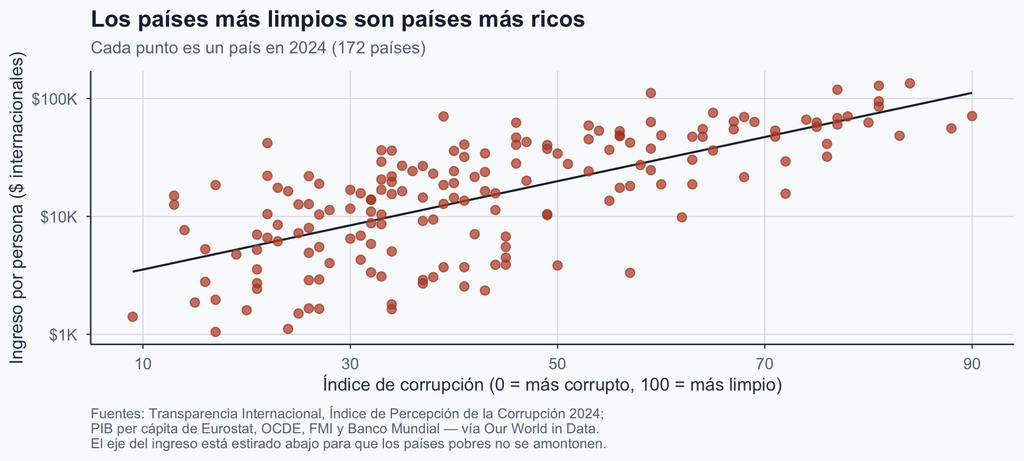

## Mauro (1995): la pregunta de Sofía en 67 países

- Sofía nos mostró por qué un soborno puede parecer **lubricante** para una empresa.
- Mauro pregunta: ¿esa lógica se sostiene en economías enteras?
- Compara **67 países**.
- Unos analistas de negocios habían calificado cuánto enfrentaban las empresas:
  - corrupción,
  - trámites burocráticos,
  - y un sistema legal ineficiente.

**Si la corrupción de verdad aceita la maquinaria, debería servir sobre todo donde los trámites son peores.**

Mauro (1995), pp. 683–687. Business International recopiló las calificaciones institucionales entre 1980 y 1983; un puntaje más alto significaba mejores instituciones.

## ¿Qué predeciría la historia del “lubricante”?

**Si la burocracia ya es rápida**

- Hay poco retraso que saltarse.
- Un soborno no debería ayudar mucho.

**Si la burocracia es dolorosamente lenta**

- Hay mucho retraso que saltarse.
- Aquí es donde el “dinero por rapidez” debería ayudar más.

**Por eso Mauro compara países con más y con menos trámites.**

## El mundo de la eficiencia burocrática de Mauro

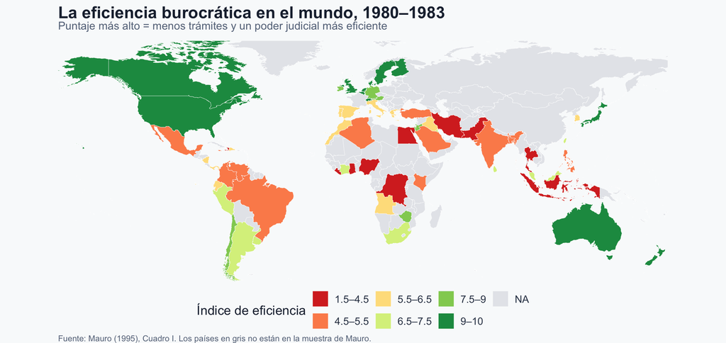

## ¿Qué pasa con la inversión cuando mejora la burocracia?

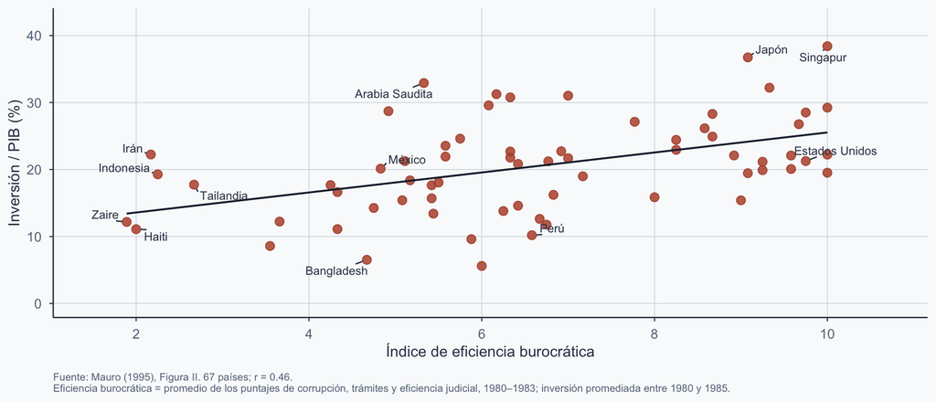

Los países con burocracias más eficientes tendían a invertir más.

Pero esta imagen por sí sola no nos dice por qué.

## ¿La corrupción ayuda donde los trámites son peores?

- Mauro separa los países con **más** y con **menos** trámites.
- Si la historia del lubricante es correcta, la corrupción debería ser menos dañina —quizá hasta útil— donde la burocracia es lenta.
- No fue así.
- Menos corrupción se asoció con **más inversión en ambos grupos**.

**La evidencia no muestra que la corrupción rescate a los países de una mala burocracia.**

Una mejora de una desviación estándar en el puntaje de corrupción se asoció con una inversión unos **2.9 puntos porcentuales del PIB más alta**.

Mauro (1995), Cuadro IV. La relación estimada entre corrupción e inversión no difirió significativamente entre países con muchos y con pocos trámites.

## ¿Pero qué causa qué?

Observamos: **Peor burocracia ↔︎ menos inversión**

Eso podría significar:

**1. Mala burocracia → menos inversión** Los sobornos y los trámites hacen que las empresas quieran invertir menos.

**2. Economías débiles → mala burocracia** Un mal desempeño económico puede dificultar sostener un gobierno eficaz.

**3. Algo más → ambas** La inestabilidad política u otras instituciones pueden producir las dos cosas.

**La correlación por sí sola no nos dice cuál historia es la correcta.**

## Mauro intenta acercarse a la causalidad

- El problema: la economía de hoy puede afectar a las instituciones de hoy.
- Por eso Mauro busca algo que quedó determinado mucho antes.
- Usa la **fragmentación etnolingüística de 1960** de cada país para predecir la calidad institucional.
- Luego pregunta si esa calidad institucional predicha se relaciona con la inversión.
- La relación negativa sobrevive.

**Pero la estrategia sólo funciona si la fragmentación afecta a la inversión principalmente a través de las instituciones.**

Mauro (1995), pp. 683, 692–698. Mauro también discute instrumentos alternativos y los límites de la estrategia.

## El rodeo, en una imagen

```
%%{init: {"flowchart": {"useMaxWidth": true, "nodeSpacing": 100, "rankSpacing": 95, "padding": 44, "wrappingWidth": 700, "curve": "basis"}, "themeVariables": {"fontSize": "20px", "fontFamily": "Verdana, Geneva, sans-serif"}, "markdownAutoWrap": false, "width": 1150, "height": 620}}%%
flowchart LR
  F["División etnolingüística<br/>en 1960"] -->|"moldea"| I["Instituciones hoy<br/>corrupción, trámites"]
  I -->|"se relaciona con"| V["Inversión hoy"]
  F -. "sin ruta directa" .-> V
  classDef early fill:#1e293b,stroke:#1e293b,color:#f9fafb,stroke-width:2px;
  classDef mid fill:#f9fafb,stroke:#4a7c6f,color:#1e293b,stroke-width:2.5px;
  classDef out fill:#f9fafb,stroke:#64748b,color:#1e293b,stroke-width:2.5px;
  class F early;
  class I mid;
  class V out;
  linkStyle 2 stroke:#b44527,stroke-width:2px,stroke-dasharray:6 6;
```

**La división de 1960 vino primero — así que esa flecha sólo puede correr en un sentido.**

Ilustración propia de la estrategia de Mauro. La ruta sólida es lo que él puede estimar. La flecha punteada es el supuesto que hay detrás: la fragmentación no debe llegar a la inversión por ninguna otra vía. El orden temporal descarta la historia inversa; a la flecha punteada no la descarta nada salvo el argumento.

## De los países de Mauro a las empresas de Uganda

- **Mauro** mostró que las burocracias más limpias se asocian con más inversión entre países.
- Pero esa evidencia era:
  - **entre países**,
  - basada en **medidas de percepción**,
  - y seguía siendo vulnerable a dudas causales.
- **Fisman y Svensson (2007)** bajan al nivel de la empresa.
- Preguntan: dentro de un mismo país, ¿las empresas que pagan más sobornos crecen más lento?

**La misma pregunta de Mauro — pero ahora dentro de una economía, con reportes directos de las empresas.**

Fisman y Svensson (2007), introducción. El artículo se presenta explícitamente como un complemento, a nivel de empresa, de la literatura entre países que inicia con Mauro (1995).

## Fisman y Svensson (2007): el diseño

- Encuesta a **243 empresas manufactureras** en Uganda
- Se preguntó a los gerentes, de forma confidencial, sobre:
  - **pagos de sobornos**,
  - **pagos de impuestos**,
  - y el desempeño de la empresa
- Sobornos e impuestos se midieron como **porcentaje de las ventas**
- Resultado: **crecimiento de la empresa**, sobre todo en ventas

Así que la comparación no es sólo **sobornos contra no sobornos**. Es:

**¿Qué tan dañinos son los sobornos frente a una carga fiscal ordinaria?**

Fisman y Svensson (2007), resumen y sección de datos. El crecimiento se mide entre 1995 y 1997.

## Lo que encontraron

- Las empresas con **tasas de soborno más altas** crecieron más lento.
- Las empresas con **tasas impositivas más altas** también crecieron más lento.
- Pero el efecto del soborno fue mucho mayor.
- A grandes rasgos:
  - **+1 punto porcentual de soborno** → cerca de **3 puntos porcentuales menos de crecimiento**
  - el efecto de los impuestos fue mucho menor

**El soborno resultó más dañino para el crecimiento de la empresa que los impuestos.**

Fisman y Svensson (2007), resumen. El artículo reporta que el efecto del soborno es entre 2.5 y 3 veces el del impuesto, según la especificación y el tratamiento de los valores atípicos.

## ¿Por qué un soborno puede doler más que un impuesto?

| Un impuesto | Un soborno |
| --- | --- |
| Se conoce de antemano | Secreto e incierto |
| Se aplica por regla | Depende del funcionario |
| Más fácil de presupuestar | Se puede renegociar o volver a exigir |
| Exigible legalmente | Ningún contrato es exigible ante un juez |
| Puede financiar bienes públicos | Sobre todo compra un atajo privado |

Así que la corrupción no es simplemente **“un impuesto cuya recaudación desaparece”.**

**También añade incertidumbre, regateo y extracción repetida.**

Shleifer y Vishny (1993), puesto a prueba a nivel de empresa por Fisman y Svensson (2007).

## ¿Cuándo el lubricante se vuelve lastre?

Volvamos a Sofía:

Los primeros dos sobornos de Sofía le sirvieron.

Pero ahora imaginen que su negocio crece:

- más embarques;
- más inspecciones;
- más permisos y autorizaciones;
- más puntos donde se puede exigir un pago;
- más incertidumbre sobre cuánto y cuándo.

**Un soborno aislado puede ayudar a una empresa. Un sistema de sobornos repetidos puede frenar su crecimiento.**

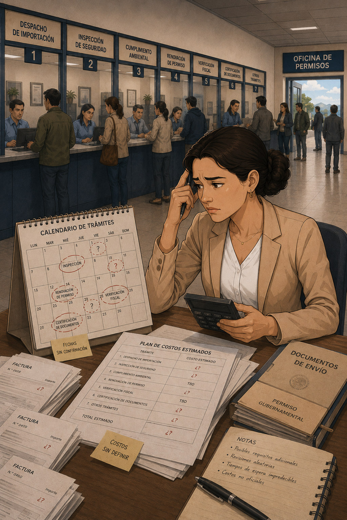

Sofía intentando planear un negocio en crecimiento mientras enfrenta exigencias oficiales repetidas.

## ¿Y entonces?

- **Mauro:** entre países, las burocracias más limpias se asocian con más inversión.
- **Fisman y Svensson:** dentro de un país, las empresas que pagan más sobornos crecen más lento.
- Y donde las rentas son grandes, el talento puede irse a capturarlas en vez de a construir cosas.
- Juntos sugieren que la corrupción tiene costos económicos reales:
  - entre economías,
  - y dentro de las empresas.
- Ahora pasamos a otro tipo de evidencia:
  - la corrupción en un proyecto público,
  - medida directamente,
  - y alterada experimentalmente.

**Sigue: ¿qué pasa cuando los investigadores escarban el camino — y algunos pueblos enfrentan auditorías por sorteo?**

Talento desviado a la búsqueda de rentas: Murphy, Shleifer y Vishny (1991), citados por Mauro (1995).

# II. Los costos en los servicios públicos

## Un pueblo, un camino y una cuarta parte que falta

- Un pueblo de Java recibe unos **US$8,800** para recubrir su camino
- El pueblo reporta, renglón por renglón, en qué lo gastó
- Después unos ingenieros escarban el camino y miden lo que realmente hay
- Cerca de **una cuarta parte** del gasto reportado no está en el suelo

Guarden ese número. Primero: **¿qué parte es una transferencia y qué parte es una pérdida social?**

[figure not shown]

Un camino en Licin, Java Oriental — una de las dos provincias del estudio de Olken.

Foto: Aryphrase, CC BY-SA 3.0, vía [Wikimedia Commons](https://commons.wikimedia.org/wiki/File:Road_at_Licin,_East_Java,_Indonesia.jpg). Ilustrativa; no es un camino del estudio.

Olken (2007). Usamos el caso para separar el dinero que cambia de manos del valor público que desaparece.

## ¿Qué se perdió exactamente?

```
%%{init: {"flowchart": {"useMaxWidth": true, "nodeSpacing": 105, "rankSpacing": 80, "padding": 48, "wrappingWidth": 700, "curve": "basis"}, "themeVariables": {"fontSize": "20px", "fontFamily": "Verdana, Geneva, sans-serif"}, "markdownAutoWrap": false, "width": 1150, "height": 620}}%%
flowchart LR
  S["Se desvían<br/>$1,000"] --> A["Alguien más recibe<br/>esos $1,000"]
  S --> B["$1,000 menos<br/>compran materiales"]
  B --> C["El pueblo recibe<br/>menos camino del que pagó"]
  classDef origin fill:#1e293b,stroke:#1e293b,color:#f9fafb,stroke-width:2px;
  classDef transfer fill:#f9fafb,stroke:#64748b,color:#1e293b,stroke-width:2.5px;
  classDef loss fill:#f9fafb,stroke:#b44527,color:#1e293b,stroke-width:2.5px;
  class S origin;
  class A transfer;
  class B,C loss;
```

**El dinero robado cambia de manos. El costo social es que el público recibe menos de lo que pagó.**

Ilustración propia. La primera rama es una transferencia; la segunda es la pérdida de valor público. Olken (2007) mide gasto y materiales faltantes, no los efectos posteriores de un camino peor.

## Olken (2007): 608 pueblos en Java

- **Indonesia**, 2003–2004
- Un programa nacional de subsidios a los pueblos, financiado por el Banco Mundial
- **608 pueblos** en **Java Central** y **Java Oriental**
- La mayoría de los proyectos: recubrir un camino de terracería con arena, piedra y grava

La unidad ya no es un país ni una empresa.

Es **un camino rural**.

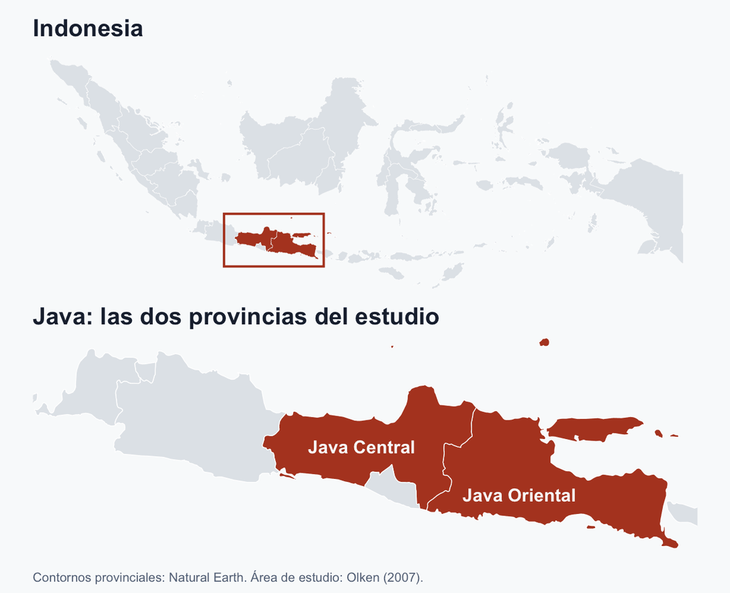

## ¿De dónde sale la comparación?

```
%%{init: {"flowchart": {"useMaxWidth": true, "nodeSpacing": 70, "rankSpacing": 78, "padding": 40, "wrappingWidth": 700, "curve": "basis"}, "themeVariables": {"fontSize": "20px", "fontFamily": "Verdana, Geneva, sans-serif"}, "markdownAutoWrap": false, "width": 1150, "height": 620}}%%
flowchart LR
  A["608 proyectos de<br/>caminos rurales"] --> L{"Sorteo"}
  L --> T["Les avisan: la<br/>auditoría es segura"]
  L --> C["Supervisión normal<br/>4% de probabilidad"]
  T --> M["Los ingenieros<br/>miden el camino"]
  C --> M
  M --> D["Diferencia =<br/>efecto de la auditoría"]
  classDef origin fill:#1e293b,stroke:#1e293b,color:#f9fafb,stroke-width:2px;
  classDef draw fill:#f9fafb,stroke:#b7943a,color:#1e293b,stroke-width:2.5px;
  classDef arm fill:#f9fafb,stroke:#64748b,color:#1e293b,stroke-width:2.5px;
  classDef out fill:#f9fafb,stroke:#b44527,color:#1e293b,stroke-width:2.5px;
  class A origin;
  class L draw;
  class T,C,M arm;
  class D out;
```

**Mauro necesitó un rodeo por 1960. Aquí, la comparación la hace un sorteo.**

Olken (2007), secciones II–III. A los pueblos se les avisó de la auditoría antes de construir el proyecto, así que el anuncio podía cambiar la conducta.

## ¿Cómo supieron lo que realmente había?

```
%%{init: {"flowchart": {"useMaxWidth": true, "nodeSpacing": 45, "rankSpacing": 95, "padding": 44, "wrappingWidth": 700, "curve": "basis"}, "themeVariables": {"fontSize": "20px", "fontFamily": "Verdana, Geneva, sans-serif"}, "markdownAutoWrap": false, "width": 1150, "height": 620}}%%
flowchart LR
  R["El reporte de gasto<br/>del propio pueblo"] --> G["Comparar"]
  S["Muestras extraídas<br/>del camino"] --> G
  W["Entrevistas con<br/>los trabajadores"] --> G
  G --> X["Cerca del 24% del gasto<br/>reportado no aparece"]
  classDef claim fill:#1e293b,stroke:#1e293b,color:#f9fafb,stroke-width:2px;
  classDef check fill:#f9fafb,stroke:#4a7c6f,color:#1e293b,stroke-width:2.5px;
  classDef mid fill:#f9fafb,stroke:#64748b,color:#1e293b,stroke-width:2.5px;
  classDef hot fill:#b44527,stroke:#b44527,color:#f9fafb,stroke-width:2.5px;
  class R claim;
  class S,W check;
  class G mid;
  class X hot;
```

**No es la impresión de un experto sobre un país. Es un número que se puede sacar del suelo.**

Olken (2007), pp. 202–203. Los ingenieros tomaron muestras del camino terminado, cotizaron materiales con proveedores locales y preguntaron a los trabajadores cuánto les pagaron.

## Las auditorías redujeron el robo

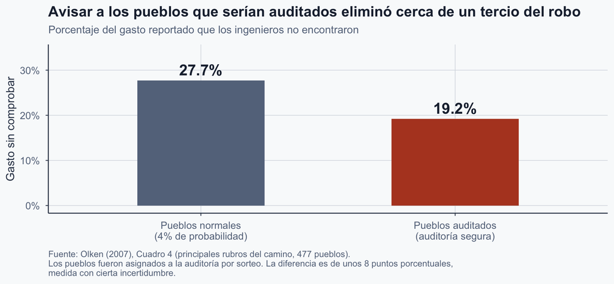

## Lo que aprendimos y lo que no

**Lo que aprendimos**

- La comparación la hizo un sorteo, no una elección
- Las auditorías anunciadas redujeron el gasto faltante cerca de un tercio
- El robo evitado valió más de lo que costaron las auditorías

**Lo que no aprendimos**

- Las auditorías no acabaron con la corrupción: cerca de una quinta parte siguió faltando
- Las asambleas comunitarias de rendición de cuentas no tuvieron efecto promedio
- Un programa, un país, un tipo de camino

**Las auditorías desde arriba movieron el número. Las asambleas desde abajo, en promedio, no.**

Olken (2007), secciones V y VI. Robo evitado ≈ $468 por pueblo frente a un costo de auditoría de ≈ $335.

# III. Cuando la corrupción se vuelve exclusión

## Sofía pudo pagar. ¿Y si tú no puedes?

- Sofía enfrentó un **atajo de $40** y podía pagarlo.
- Pagar fue racional en lo privado: evitó unos **$500** en pérdidas.
- Pero tratar con el Estado no siempre es una elección.
- Y no todos pueden comprar el atajo.

**El mismo pago es un atajo para una persona y una barrera para otra.**

## Cómo la corrupción se vuelve un costo personal

```
%%{init: {"flowchart": {"useMaxWidth": true, "nodeSpacing": 45, "rankSpacing": 75, "padding": 40, "wrappingWidth": 700, "curve": "basis"}, "themeVariables": {"fontSize": "20px", "fontFamily": "Verdana, Geneva, sans-serif"}, "markdownAutoWrap": false, "width": 1150, "height": 620}}%%
flowchart LR
  M["Una desgracia, o<br/>un trámite común"] --> S["Necesitas una<br/>oficina pública"]
  S --> B["Un funcionario<br/>pide un pago"]
  B --> P["Puedes pagar"]
  B --> N["No puedes pagar"]
  P --> A["Recibes el servicio,<br/>y pagas de más"]
  N --> X["Lo aplazas, lo dejas,<br/>o te quedas sin él"]
  classDef origin fill:#1e293b,stroke:#1e293b,color:#f9fafb,stroke-width:2px;
  classDef step fill:#f9fafb,stroke:#64748b,color:#1e293b,stroke-width:2.5px;
  classDef pay fill:#f9fafb,stroke:#4a7c6f,color:#1e293b,stroke-width:2.5px;
  classDef gone fill:#f9fafb,stroke:#b44527,color:#1e293b,stroke-width:2.5px;
  class M origin;
  class S,B step;
  class P,A pay;
  class N,X gone;
```

**Tres preguntas distintas: quién termina en la ventanilla, cuánto le cuesta el pago y qué pasa si se da la vuelta.**

## Ejercicio · Ustedes están a cargo

Su ciudad tiene un problema de corrupción. Su equipo controla **$1 millón**.

**Equipos de cuatro — 5 minutos.** Elijan **un** ámbito que les importe:

Policía · Hospitales · Permisos · Obra pública · Universidades · el suyo

**Luego respondan tres preguntas:**

1. ¿Cuál es el **mayor daño** que causa ahí la corrupción?
2. ¿En qué **una sola cosa** gastarían el millón para reducirlo?
3. ¿Qué de lo visto hoy les hace pensar que **funcionaría**?

## Presentación — 30 segundos por equipo

**Elegimos** ______

**El problema principal es** ______

**Gastaríamos el dinero en** ______ **porque** ______

**Después votamos: ¿qué propuesta financiarían de verdad?**

Ningún equipo puede votar por sí mismo.

## Un enigma, cuatro respuestas

- **Sofía:** un soborno puede ser beneficioso en lo privado.
- **Empresas y economías:** la corrupción puede convivir con menos inversión y menor crecimiento.
- **Servicios públicos:** los recursos desviados pueden dejar a la sociedad con menos de lo que pagó.
- **Hogares:** los pagos no oficiales pueden convertir el acceso al Estado en exclusión.

**El costo de la corrupción no es sólo el dinero que cambia de manos. Es lo que el sistema hace que la gente deje de hacer.**

Próxima sesión: Estados Unidos — cómo se construyó el patronazgo y cómo la reforma le quitó el favor a los políticos.

## Referencias (1 de 3)

Fisman, R., & Svensson, J. (2007). Are corruption and taxation really harmful to growth? Firm level evidence. *Journal of Development Economics, 83*(1), 63–75. https://doi.org/10.1016/j.jdeveco.2005.09.009

Hunt, J. (2007). How corruption hits people when they are down. *Journal of Development Economics, 84*(2), 574–589. https://doi.org/10.1016/j.jdeveco.2007.02.003

Hunt, J., & Laszlo, S. (2012). Is bribery really regressive? Bribery’s costs, benefits, and mechanisms. *World Development, 40*(2), 355–372. https://doi.org/10.1016/j.worlddev.2011.07.015

Huntington, S. P. (1968). *Political order in changing societies*. Yale University Press.

Leff, N. H. (1964). Economic development through bureaucratic corruption. *American Behavioral Scientist, 8*(3), 8–14. https://doi.org/10.1177/000276426400800303

## Referencias (2 de 3)

Mauro, P. (1995). Corruption and growth. *The Quarterly Journal of Economics, 110*(3), 681–712. https://doi.org/10.2307/2946696

Murphy, K. M., Shleifer, A., & Vishny, R. W. (1991). The allocation of talent: Implications for growth. *The Quarterly Journal of Economics, 106*(2), 503–530.

Olken, B. A. (2007). Monitoring corruption: Evidence from a field experiment in Indonesia. *Journal of Political Economy, 115*(2), 200–249. https://doi.org/10.1086/517935

Olken, B. A. (2009). Corruption perceptions vs. corruption reality. *Journal of Public Economics, 93*(7–8), 950–964. https://doi.org/10.1016/j.jpubeco.2009.03.001

Rose-Ackerman, S. (1978). *Corruption: A study in political economy*. Academic Press.

## Referencias (3 de 3)

Shleifer, A., & Vishny, R. W. (1993). Corruption. *The Quarterly Journal of Economics, 108*(3), 599–617. https://doi.org/10.2307/2118402

Transparency International. (2025). *Corruption Perceptions Index 2024*. https://www.transparency.org/en/cpi/2024

Treisman, D. (2007). What have we learned about the causes of corruption from ten years of cross-national empirical research? *Annual Review of Political Science, 10*, 211–244. https://doi.org/10.1146/annurev.polisci.10.081205.095418